# BRAZILIAN COFFEE PRODUCTION (1961-2015)

Andriy Gorshkov

18 Dezember 2018

## Production

Let’s look at Diagram 1 of the production of coffee between 1960 and 2015 crops years. Here you can see the productivity (1000 tonnes) and harvested area (1000 ha)[^1].

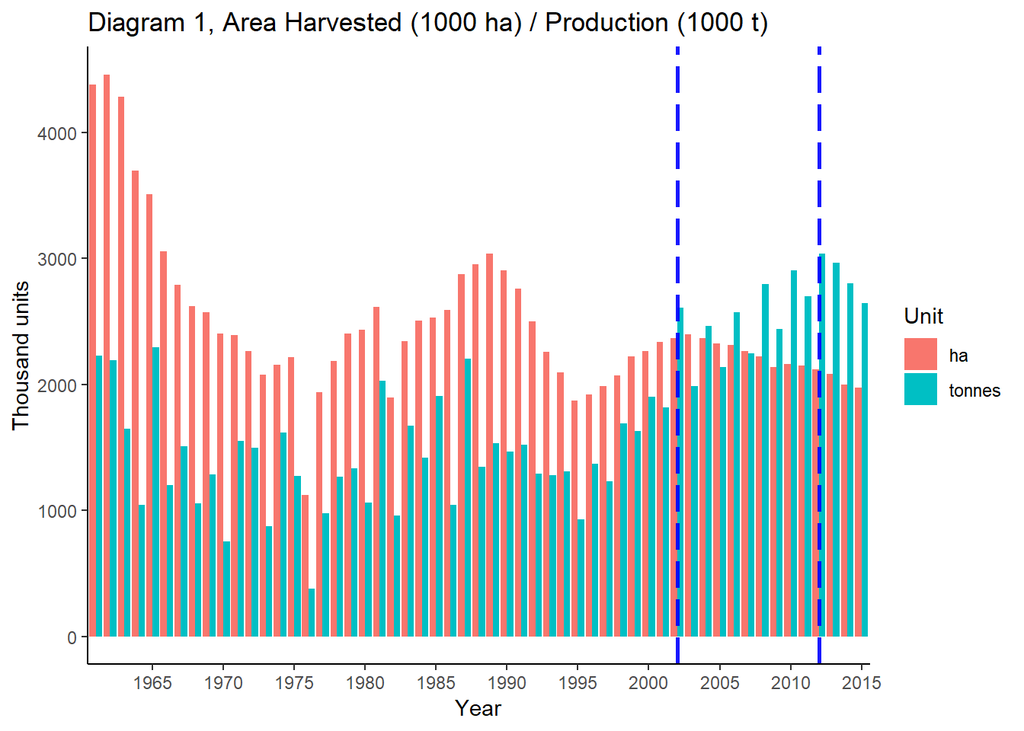

## Weather

Of course, the significant effect for the coffee crop makes the weather (Diagram 2 and Diagram 3)[^2]:

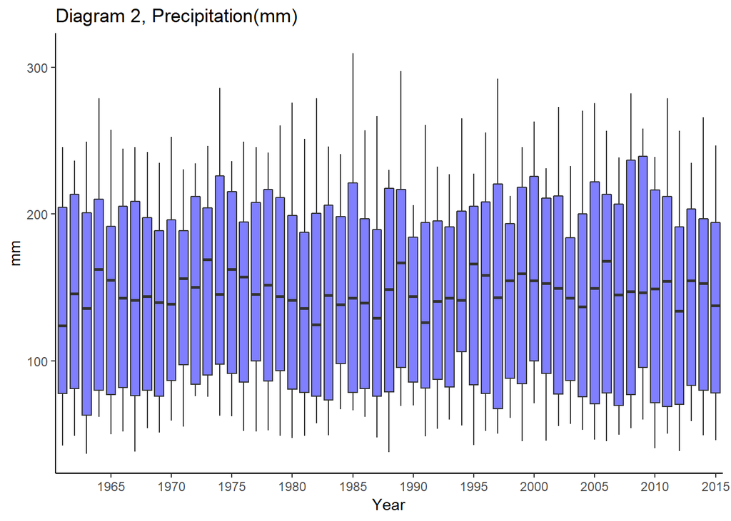

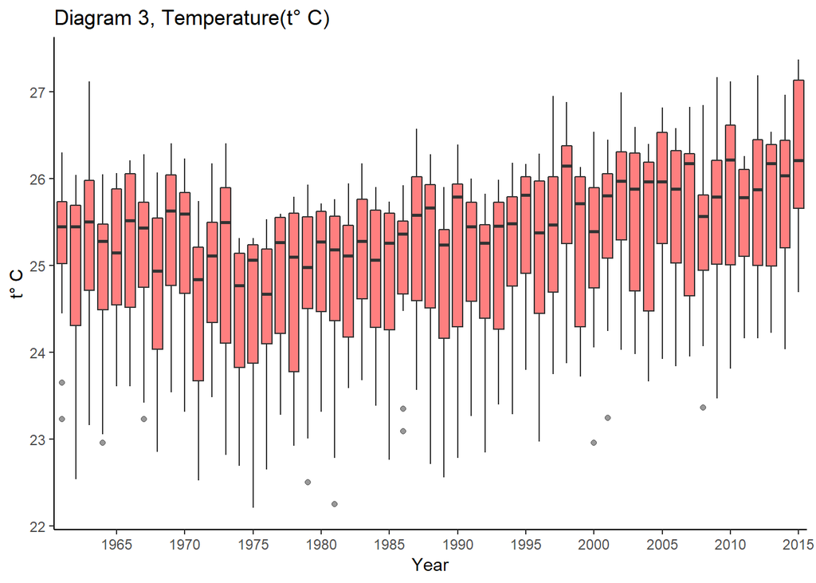

## Linear models

The dependent variable in our model is Production in tonns. Predictor-variables: harvested area (ha), Precipitation (pr) and temperature (t_cel).

### Normality test

Quantile-Comparison Plots and Shapiro-Wilk normality tests:

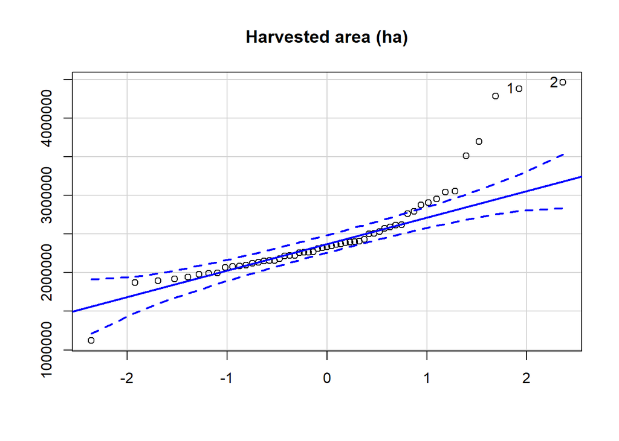

p-value = 1.318485510^{-6} If the P-value less then 0.05 then it means that we have got not a normal distribution for observation. But another side, if we exclude some of the observations, Quantile-Comparison Plot show us enough normal distribution.

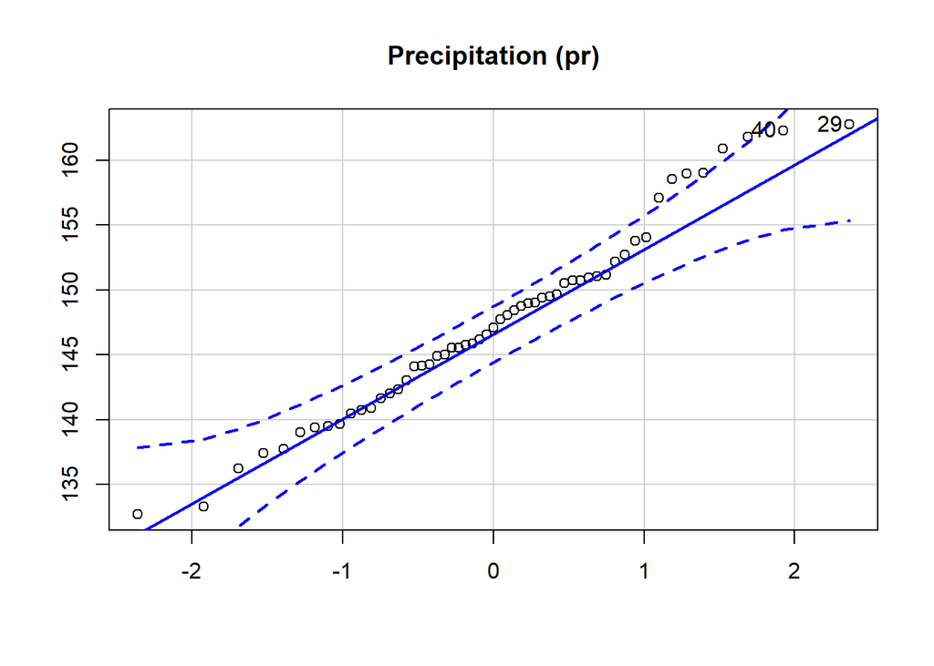

p-value = 0.3639256

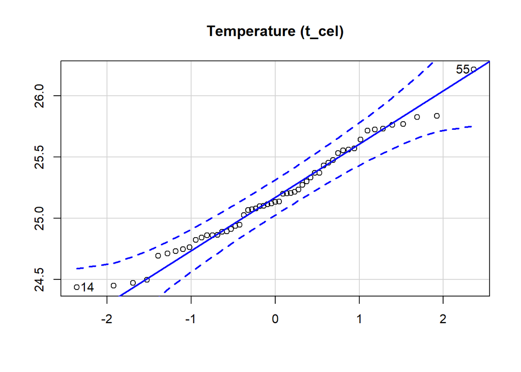

p-value = 0.5292238

### Lack of perfect multicollinearity in the predictors test:

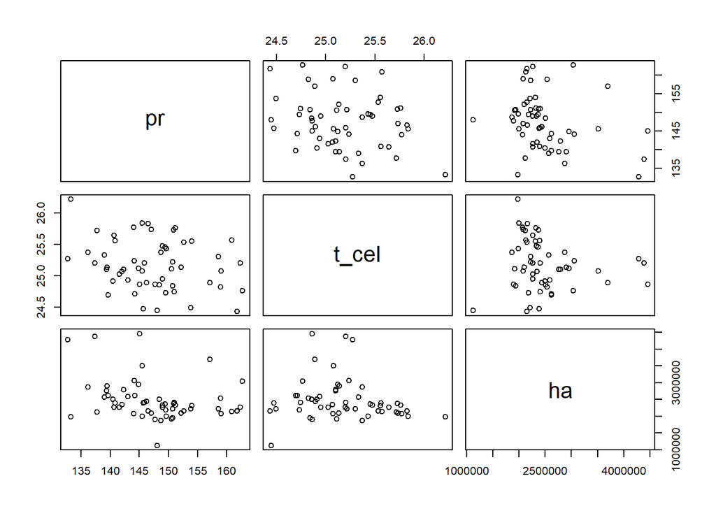

Obviously, there is no multicollinearity in the predictors.

### Durbin-Watson test for autocorrelation of disturbances:

```
##
##  Durbin-Watson test
##
## data:  tonnes ~ pr + t_cel + ha
## DW = 1.8078, p-value = 0.162
## alternative hypothesis: true autocorrelation is greater than 0
```

### Breusch-Pagan test against heteroskedasticity:

```
##
##  studentized Breusch-Pagan test
##
## data:  tonnes ~ pr + t_cel + ha
## BP = 0.44166, df = 3, p-value = 0.9315
```

### Model 1

Let’s try to fit the model without interaction between the predictors (Table 1, Model 1):

Table 1, Model 1 tonnes ~ pr + t_cel + ha

|  | Estimate | Std. Error | t value | Pr(>\|t\|) |
| --- | --- | --- | --- | --- |
| (Intercept) | -3.117467e+07 | 4.971264e+06 | -6.270974 | 0.0000001 |
| pr | 1.599586e+04 | 9.662241e+03 | 1.655503 | 0.1039641 |
| t_cel | 1.190059e+06 | 1.697268e+05 | 7.011615 | 0.0000000 |
| ha | 2.335052e-01 | 1.113696e-01 | 2.096669 | 0.0410019 |

Adjusted R-squared: 0.465218

P-Value: 1.129652910^{-7}

### Model 2

and with an interaction between the Precipitation (pr) and the temperature (t_cel) predictors (Table 2, Model 2):

Table 2, Model 2 tonnes ~ pr * t_cel + ha

|  | Estimate | Std. Error | t value | Pr(>\|t\|) |
| --- | --- | --- | --- | --- |
| (Intercept) | -5.690415e+07 | 7.800792e+07 | -0.7294663 | 0.4691201 |
| pr | 1.907866e+05 | 5.289325e+05 | 0.3607011 | 0.7198423 |
| t_cel | 2.210766e+06 | 3.092970e+06 | 0.7147712 | 0.4780746 |
| ha | 2.357544e-01 | 1.125610e-01 | 2.0944582 | 0.0413079 |
| pr:t_cel | -6.936898e+03 | 2.098812e+04 | -0.3305155 | 0.7423915 |

Adjusted R-squared: 0.4557115

P-Value: 4.867017210^{-7}

### Prediction overview

The adjusted R-squared and the P-Values of both models are very close to each other. So maybe it makes no sense to complicate the model. Let’s build predictions based on these two models and show them on Diagram 4:

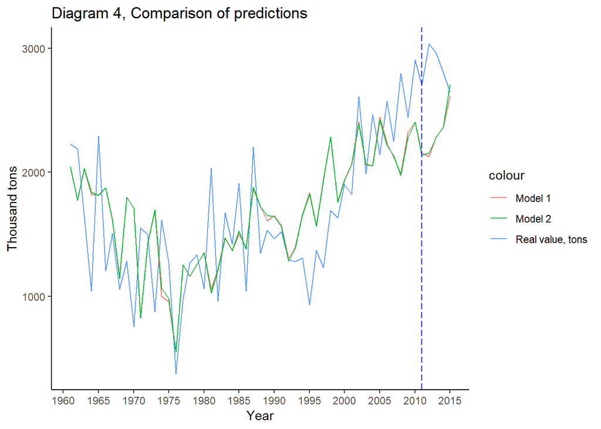

We can note that substantial productivity was significantly increased between 2002 and 2012 (Diagram 1) and our predictions works after that not so good as before. But I assume, that after the boom of the technical progress the models will show better result or we need to include another predictor, like Investing in the agriculture sector.

## Improving model

Maybe we can improve the model if we define the most important months for crop. But let’s analyze, how to impact previous year for the crop of the current year.

temperature

| Year | 1 | 2 | 3 | 4 | 5 | 6 | 7 | 8 | 9 | 10 | 11 | 12 |
| --- | --- | --- | --- | --- | --- | --- | --- | --- | --- | --- | --- | --- |
| 1900 | 25.4428 | 25.6852 | 25.4134 | 24.6807 | 24.2498 | 23.6233 | 23.9889 | 24.5464 | 25.4163 | 25.9019 | 25.3493 | 25.2841 |
| 1901 | 25.4154 | 25.8780 | 25.5431 | 25.2931 | 24.7728 | 24.3457 | 24.0495 | 23.6911 | 25.4080 | 25.5335 | 25.9746 | 26.0127 |
| 1902 | 25.3233 | 25.7234 | 25.7457 | 25.0774 | 24.1325 | 24.0238 | 23.7238 | 24.1607 | 25.2533 | 25.3112 | 25.4216 | 25.7167 |
| 1903 | 25.0649 | 25.4235 | 25.2458 | 24.9627 | 23.6202 | 23.0570 | 23.4130 | 23.8104 | 24.9000 | 25.1578 | 25.3359 | 25.2219 |
| 1904 | 25.1291 | 25.4753 | 24.9352 | 24.6405 | 24.6035 | 23.8587 | 23.4819 | 24.1923 | 25.0692 | 26.2031 | 25.6534 | 25.7393 |

Precipitation

| Year | 1 | 2 | 3 | 4 | 5 | 6 | 7 | 8 | 9 | 10 | 11 | 12 |
| --- | --- | --- | --- | --- | --- | --- | --- | --- | --- | --- | --- | --- |
| 1900 | 230.256 | 220.684 | 241.885 | 174.373 | 122.834 | 74.0658 | 69.8303 | 59.4876 | 76.5292 | 117.080 | 151.496 | 205.056 |
| 1901 | 214.472 | 213.322 | 241.489 | 173.213 | 122.284 | 74.5530 | 61.4888 | 67.7738 | 77.0399 | 128.343 | 162.622 | 213.075 |
| 1902 | 226.419 | 213.960 | 225.146 | 169.193 | 125.836 | 77.3882 | 58.5319 | 56.9653 | 75.2839 | 125.352 | 155.804 | 205.983 |
| 1903 | 232.043 | 213.260 | 221.466 | 172.176 | 123.379 | 75.4700 | 63.7302 | 57.2912 | 75.1994 | 139.923 | 144.555 | 191.066 |
| 1904 | 220.974 | 215.271 | 238.077 | 171.956 | 133.824 | 74.8215 | 63.8506 | 62.2261 | 80.2008 | 130.492 | 151.986 | 203.371 |

```
##
## Call:
## lm(formula = tonnes ~ ., data = twelve_m_t[-1])
##
## Residuals:
##      Min       1Q   Median       3Q      Max
## -1109491  -297595    23381   252318   980067
##
## Coefficients:
##               Estimate Std. Error t value Pr(>|t|)
## (Intercept) -2.623e+07  5.488e+06  -4.778 2.39e-05 ***
## ha           1.308e-01  1.200e-01   1.090   0.2824
## `1`         -1.014e+05  3.527e+05  -0.287   0.7753
## `2`         -4.042e+04  3.651e+05  -0.111   0.9124
## `3`          5.302e+05  3.169e+05   1.673   0.1021
## `4`         -1.957e+05  2.650e+05  -0.739   0.4645
## `5`         -2.463e+04  2.067e+05  -0.119   0.9057
## `6`          3.643e+05  1.789e+05   2.036   0.0484 *
## `7`         -2.535e+05  1.830e+05  -1.386   0.1736
## `8`          1.420e+05  1.986e+05   0.715   0.4787
## `9`          2.472e+05  1.661e+05   1.488   0.1445
## `10`         1.755e+05  2.269e+05   0.773   0.4438
## `11`         2.285e+05  2.607e+05   0.877   0.3859
## `12`         1.167e+04  2.887e+05   0.040   0.9680
## ---
## Signif. codes:  0 '***' 0.001 '**' 0.01 '*' 0.05 '.' 0.1 ' ' 1
##
## Residual standard error: 469100 on 40 degrees of freedom
## Multiple R-squared:  0.5958, Adjusted R-squared:  0.4644
## F-statistic: 4.536 on 13 and 40 DF,  p-value: 0.0001063
```

```
##
## Call:
## lm(formula = tonnes ~ ., data = twelve_m_p[-1])
##
## Residuals:
##     Min      1Q  Median      3Q     Max
## -855331 -257579  -18778  211543 1216143
##
## Coefficients:
##               Estimate Std. Error t value Pr(>|t|)
## (Intercept)  1.119e+06  1.895e+06   0.591  0.55805
## ha           2.023e-02  1.240e-01   0.163  0.87124
## `1`         -1.870e+03  3.155e+03  -0.593  0.55658
## `2`          1.129e+04  3.837e+03   2.943  0.00539 **
## `3`          2.809e+03  3.614e+03   0.777  0.44159
## `4`         -4.391e+03  5.422e+03  -0.810  0.42285
## `5`          1.626e+04  6.437e+03   2.526  0.01562 *
## `6`         -2.405e+03  7.126e+03  -0.337  0.73755
## `7`          6.923e+02  8.684e+03   0.080  0.93686
## `8`          1.140e+04  9.106e+03   1.252  0.21788
## `9`         -1.939e+04  7.374e+03  -2.630  0.01207 *
## `10`        -1.360e+04  5.164e+03  -2.634  0.01193 *
## `11`        -3.335e+03  5.568e+03  -0.599  0.55267
## `12`        -1.814e+03  3.202e+03  -0.567  0.57420
## ---
## Signif. codes:  0 '***' 0.001 '**' 0.01 '*' 0.05 '.' 0.1 ' ' 1
##
## Residual standard error: 523300 on 40 degrees of freedom
## Multiple R-squared:  0.4971, Adjusted R-squared:  0.3336
## F-statistic: 3.041 on 13 and 40 DF,  p-value: 0.003425
```

So, let’s use the month 6 with observation for “temperature” and 2, 5, 9, 10 with observation for precipitation. And we got follow table for the model:

| Year | ha | tonnes | t6 | p2p | p5p | p9p | p10p |
| --- | --- | --- | --- | --- | --- | --- | --- |
| 1961 | 4383820 | 2228704 | 22.8358 | 219.023 | 140.353 | 78.3526 | 117.8920 |
| 1962 | 4462657 | 2190303 | 23.1624 | 249.152 | 110.085 | 54.0583 | 88.9560 |
| 1963 | 4286129 | 1650527 | 22.9543 | 238.132 | 161.528 | 73.8621 | 146.5920 |
| 1964 | 3696281 | 1042013 | 23.8373 | 189.352 | 123.886 | 71.8418 | 151.2220 |
| 1965 | 3511079 | 2294047 | 23.8783 | 244.330 | 138.778 | 79.6178 | 113.0210 |
| 1966 | 3057470 | 1202868 | 23.2286 | 225.067 | 121.471 | 61.6041 | 90.0765 |

### Improved model

```
##
## Call:
## lm(formula = tonnes ~ ., data = twelve_m[-1])
##
## Residuals:
##     Min      1Q  Median      3Q     Max
## -778073 -287637  -39012  333794 1126965
##
## Coefficients:
##               Estimate Std. Error t value Pr(>|t|)
## (Intercept) -1.295e+07  3.092e+06  -4.190 0.000122 ***
## ha           1.437e-01  9.929e-02   1.448 0.154319
## t6           5.167e+05  1.160e+05   4.455 5.17e-05 ***
## p2p          9.804e+03  2.806e+03   3.494 0.001048 **
## p5p          1.235e+04  4.134e+03   2.987 0.004470 **
## p9p         -1.189e+04  4.978e+03  -2.389 0.020985 *
## p10p        -6.581e+03  3.919e+03  -1.679 0.099732 .
## ---
## Signif. codes:  0 '***' 0.001 '**' 0.01 '*' 0.05 '.' 0.1 ' ' 1
##
## Residual standard error: 426100 on 47 degrees of freedom
## Multiple R-squared:  0.6082, Adjusted R-squared:  0.5582
## F-statistic: 12.16 on 6 and 47 DF,  p-value: 3.324e-08
```

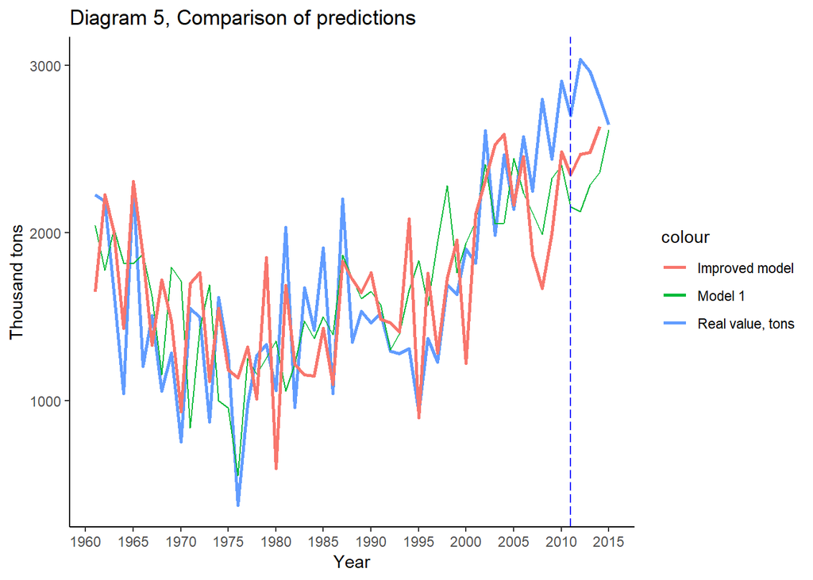

[^1]: [FAO Stat](http://www.fao.org/faostat/en/#data/QC)
[^2]: [Climate Change Knowledge Portal](http://sdwebx.worldbank.org/climateportal/index.cfm?page=downscaled_data_download&menu=historical)